# TP Théorie et codage de l'information

## Etudiant : Moncef REJEB SFAR

## Lab 1

Question 1 et 2 :

Remarque : on peut spécifier les probabilités d'apparition de 0 et 1 avec np.random.choice. D'autre part, plus la taille des données est grande plus l'entropie tend vers 1

```python
#lab 1
#Question 1 et 2
import numpy as np
import math
import matplotlib.pyplot as plt
size=30 # à régler
tableau=np.random.choice(2, size, p=[0.5, 0.5]) # p contient les probabilités d'apparition de 0 et de 1 à spécifier
print("les données : ",tableau)
counts = np.unique(tableau, return_counts=True)
nbofones=counts[1][1]
nbofzeros=counts[1][0]
probabilityOfones=nbofones/size
probabilityOfzeros=nbofzeros/size
entropy=-probabilityOfones*math.log(probabilityOfones,2)-probabilityOfzeros*math.log(probabilityOfzeros,2)
print("l'entropie est : ",entropy) #if we choose a long size entropy will be more close to 1
```

```
les données :  [0 0 0 0 0 1 0 0 1 1 0 1 0 1 0 0 1 1 1 1 1 0 1 0 1 0 1 0 1 0]
l'entropie est :  0.9967916319816366
```

### Question 3

Tracage de l'entropie en fonction de p [X=0]. (j'ai tracé une courbe de 100 points) les tableaux des abcisses et des ordonnées sont également fournis

```
voici le tableau des probas de zeros (axes des abscisse avec courbe de 100 points)
 [0.   0.01 0.02 0.03 0.04 0.05 0.06 0.07 0.08 0.09 0.1  0.11 0.12 0.13
 0.14 0.15 0.16 0.17 0.18 0.19 0.2  0.21 0.22 0.23 0.24 0.25 0.26 0.27
 0.28 0.29 0.3  0.31 0.32 0.33 0.34 0.35 0.36 0.37 0.38 0.39 0.4  0.41
 0.42 0.43 0.44 0.45 0.46 0.47 0.48 0.49 0.5  0.51 0.52 0.53 0.54 0.55
 0.56 0.57 0.58 0.59 0.6  0.61 0.62 0.63 0.64 0.65 0.66 0.67 0.68 0.69
 0.7  0.71 0.72 0.73 0.74 0.75 0.76 0.77 0.78 0.79 0.8  0.81 0.82 0.83
 0.84 0.85 0.86 0.87 0.88 0.89 0.9  0.91 0.92 0.93 0.94 0.95 0.96 0.97
 0.98 0.99 1.  ]
voici le tableau des entropies (axes des ordonnées)
 [0.         0.08079314 0.14144054 0.19439186 0.24229219 0.28639696
 0.32744492 0.36592365 0.40217919 0.43646982 0.46899559 0.49991596
 0.52936087 0.55743819 0.58423881 0.6098403  0.63430955 0.65770478
 0.68007705 0.70147146 0.72192809 0.74148274 0.7601675  0.7780113
 0.79504028 0.81127812 0.82674637 0.84146464 0.85545081 0.86872125
 0.8812909  0.89317346 0.90438146 0.91492637 0.9248187  0.93406806
 0.94268319 0.95067209 0.95804202 0.96479955 0.97095059 0.97650047
 0.9814539  0.98581504 0.98958752 0.99277445 0.99537844 0.99740159
 0.99884554 0.99971144 1.         0.99971144 0.99884554 0.99740159
 0.99537844 0.99277445 0.98958752 0.98581504 0.9814539  0.97650047
 0.97095059 0.96479955 0.95804202 0.95067209 0.94268319 0.93406806
 0.9248187  0.91492637 0.90438146 0.89317346 0.8812909  0.86872125
 0.85545081 0.84146464 0.82674637 0.81127812 0.79504028 0.7780113
 0.7601675  0.74148274 0.72192809 0.70147146 0.68007705 0.65770478
 0.63430955 0.6098403  0.58423881 0.55743819 0.52936087 0.49991596
 0.46899559 0.43646982 0.40217919 0.36592365 0.32744492 0.28639696
 0.24229219 0.19439186 0.14144054 0.08079314 0.        ]
```

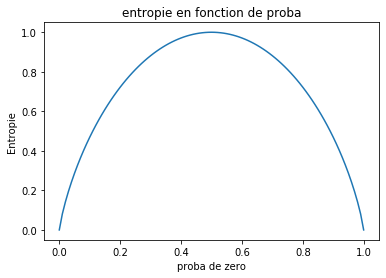

```python
#lab 1
#Question 3
import matplotlib.pyplot as plt

tabOfprobabilitiesOfzero=np.zeros(101)
for i in range(0,101):
    tabOfprobabilitiesOfzero[i]=i/100
print("voici le tableau des probas de zeros (axes des abscisse avec courbe de 100 points)\n",tabOfprobabilitiesOfzero)
tabOfEntropies=np.zeros(101)
for i in range(1,100):
    tabOfEntropies[i]=-tabOfprobabilitiesOfzero[i]*math.log(tabOfprobabilitiesOfzero[i],2)-(1-tabOfprobabilitiesOfzero[i])*math.log(1-tabOfprobabilitiesOfzero[i],2)
print("voici le tableau des entropies (axes des ordonnées)\n",tabOfEntropies)
plt.plot(tabOfprobabilitiesOfzero,tabOfEntropies)
plt.ylabel('Entropie')
plt.xlabel("proba de zero")
plt.title("entropie en fonction de proba")
plt.show()
```

### Question 4

Cette question, étant calculatoire et ne demandant pas de code, a été refaite sur papier que vous trouverez ci-dessous

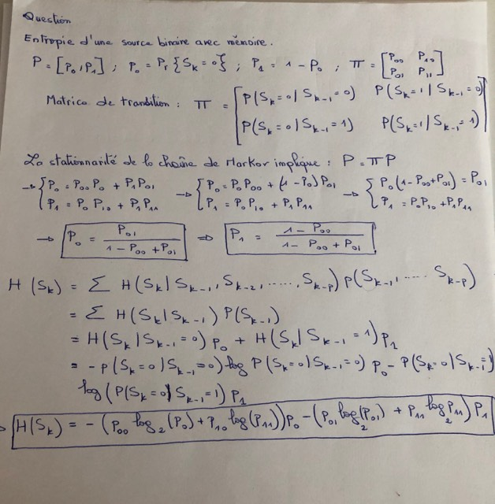

```python
#lab 1
#Question 4
from IPython.display import Image
Image("markov.jpg")
```

### Question 5

Dans cette question, nous allons travailler sur l'image donnée sur moodle. D'abord on va représenter l'image sous forme de matrice binaire (1 si pixel noir et 0 sinon) Ensuite on va faire du comptage du nombre de 0 et de 1 et du nombre de 0 (resp 1) sachant qu'on a eu 1 (resp 0). On obtient alors les 4 probabilités permettant d'afficher la matrice de transition. Enfin, nous allons nous servir de la question 4 pour calculer les entropies avec et sans mémoire et les comparer

```python
import numpy as np
from PIL import Image
from scipy import *
image = Image.open('scan.png')
pix = np.array(image)
print("Voici la matrice qui représente l'image  de facon binaire (1 si noir et 0 sinon)")
print(pix)
counts = np.unique(pix, return_counts=True)
nbofones=counts[1][1]
nbofzeros=counts[1][0]
print("Nombre de zero  :",nbofzeros)
print("Nombre de un    :",nbofones)
nbZeroSachantZero=0
nbUnSachantUn=0
nbUnSachantZero=0
nbZeroSachantUn=0
for i in range(0,pix.shape[0]):
    for j in range(0,pix.shape[1]):
        if(pix[i][j-1]==0 and pix[i][j]==0):
            nbZeroSachantZero+=1
        elif(pix[i][j-1]==1 and pix[i][j]==1):
            nbUnSachantUn+=1
        elif(pix[i][j-1]==0 and pix[i][j]==1):
            nbUnSachantZero+=1
        else:
            nbZeroSachantUn+=1

print("\nLe Nombre de zero sachant que on a eu zero avant est : ",nbZeroSachantZero)
print("Le Nombre de zero sachant que on a eu un avant est : ",nbZeroSachantUn)
print("Le Nombre de un sachant que on a eu zero avant est : ",nbUnSachantZero)
print("Le Nombre de un sachant que on a eu un avant est : ",nbUnSachantUn)
print("\nla proba d'avoir 0 sachant qu'on a eu 0 est : ",nbZeroSachantZero/nbofzeros)
print("la proba d'avoir 0 sachant qu'on a eu 1 est : ",nbZeroSachantUn/nbofones)
print("la proba d'avoir 1 sachant qu'on a eu 0 est : ",nbUnSachantZero/nbofzeros)
print("la proba d'avoir 1 sachant qu'on a eu 1 est : ",nbUnSachantUn/nbofones)
TransitionMatrix=zeros((2,2))
TransitionMatrix[0][0]=(nbZeroSachantZero)/nbofzeros
TransitionMatrix[0][1]=nbUnSachantZero/nbofzeros
TransitionMatrix[1][0]=nbZeroSachantUn/nbofones
TransitionMatrix[1][1]=nbUnSachantUn/nbofones
prob0=TransitionMatrix[1][0]/(1-TransitionMatrix[0][0]+TransitionMatrix[1][0])
prob1=1-prob0
print("\nla matrice de transition est donc : \n",TransitionMatrix)
print("\nRemarque : On voit que la proba d'avoir 1(resp 0) est tres élevée lorsqu'on a déja eu 1 (resp 0) ce qui est logique")
entropy=-(TransitionMatrix[0][0]*math.log(TransitionMatrix[0][0],2)+TransitionMatrix[0][1]*math.log(TransitionMatrix[0][1],2))*prob0-(TransitionMatrix[1][0]*math.log(TransitionMatrix[1][0],2)+TransitionMatrix[1][1]*math.log(TransitionMatrix[1][1],2))*prob1
print("l'entropie H(Sk) avec mémoire est : ",entropy)
print("\n\nP[x=0]= ",prob0)
print("P[x=1]= ",prob1)
print("l'entropie sans mémoire est donc : ",-prob0*math.log(prob0,2)-prob1*math.log(prob1,2))
print("\nRemarque : On voit que l'entropie sans mémoire est supérieure car on a moins d'informations ce qui est logique")
```

```
Voici la matrice qui représente l'image  de facon binaire (1 si noir et 0 sinon)
[[1 1 1 ... 1 1 1]
 [1 1 1 ... 1 1 1]
 [1 1 1 ... 1 1 1]
 ...
 [1 1 1 ... 1 1 1]
 [1 1 1 ... 1 1 1]
 [1 1 1 ... 1 1 1]]
Nombre de zero  : 414778
Nombre de un    : 8000222

Le Nombre de zero sachant que on a eu zero avant est :  307881
Le Nombre de zero sachant que on a eu un avant est :  106897
Le Nombre de un sachant que on a eu zero avant est :  106897
Le Nombre de un sachant que on a eu un avant est :  7893325

la proba d'avoir 0 sachant qu'on a eu 0 est :  0.7422790022614507
la proba d'avoir 0 sachant qu'on a eu 1 est :  0.013361754211320636
la proba d'avoir 1 sachant qu'on a eu 0 est :  0.2577209977385493
la proba d'avoir 1 sachant qu'on a eu 1 est :  0.9866382457886793

la matrice de transition est donc :
 [[0.742279   0.257721  ]
 [0.01336175 0.98663825]]

Remarque : On voit que la proba d'avoir 1(resp 0) est tres élevée lorsqu'on a déja eu 1 (resp 0) ce qui est logique
l'entropie H(Sk) avec mémoire est :  0.13787048776697028


P[x=0]=  0.04929031491384433
P[x=1]=  0.9507096850861557
l'entropie sans mémoire est donc :  0.2833745831777161

Remarque : On voit que l'entropie sans mémoire est supérieure car on a moins d'informations ce qui est logique
```

### Question 6

Dans cette question,j'ai d'abord fait une fonction d'encodage RLE et je l'ai testée sur une chaine de caractère Ensuite j'ai appliqué cette fonction aux 220 premieres lignes de la matrice calculée précédemment ( le resultat sur toute l'image est trop long et illisible)

```python
#Question 6 encoder RLE
import re
from scipy import *
from PIL import Image
import numpy as np
image = Image.open('scan.png')
pix = np.array(image)
print("Voici la matrice qui représente l'image  de facon binaire (1 si noir et 0 sinon)")
print(pix)
ch=""
#RLE(run-length encoding) encoder
def encode(string):
    if string == '':
        return ''
    i = 0
    count = 0
    letter = string[i]
    rle = []
    while i <= len(string) - 1:
        while string[i] == letter:
            i+= 1
            count +=1
            #catch the loop on last character so it doesn't got to top and access out of bounds
            if i > len(string) - 1:
                break

        rle.append('{1}{0}'.format(count, letter))
        if i > len(string) - 1:
            break
        letter = string[i]
        count = 0
    #join list of strings together to create one string to return
    final = ''.join(rle)
    return final
print("\nTest de la fonction d'encodage sur la chaine: wwwwwwwwwwwbjwwwlpppzeeezzaaaaa\n",encode("wwwwwwwwwwwbjwwwlpppzeeezzaaaaa"))
print("\nApplication de RLE sur notre image de moodle (chaque ligne du tableau est transformée en chaine et encodée:\n")
print("Seul l'encodage des 220 premieres lignes est affiché")
for i in range(0,220):
    for j in range(0,pix.shape[1]):
        if pix[i][j]==0:
            ch+="0"
        else:
            ch+="1"
print(encode(ch))
```

```
Voici la matrice qui représente l'image  de facon binaire (1 si noir et 0 sinon)
[[1 1 1 ... 1 1 1]
 [1 1 1 ... 1 1 1]
 [1 1 1 ... 1 1 1]
 ...
 [1 1 1 ... 1 1 1]
 [1 1 1 ... 1 1 1]
 [1 1 1 ... 1 1 1]]

Test de la fonction d'encodage sur la chaine: wwwwwwwwwwwbjwwwlpppzeeezzaaaaa
 w11b1j1w3l1p3z1e3z2a5

Application de RLE sur notre image de moodle (chaque ligne du tableau est transformée en chaine et encodée:

Seul l'encodage des 220 premieres lignes est affiché
154090102156021400211602111402168041860217203160311600217102…
```